# Machine Learning Classification

# Model Evaluation

- OK, let’s go back to the idea of model evaluation. How good is our model?
- Let’s fit our null model on the training data, then evaluate how good it is on the testing dataset.

```r
prop.table(table(creditTrain$card))
```

```
##
##        no       yes
## 0.2242424 0.7757576
```

```r
## The prob of yes is equal to 0.776
```

- We will guess that the probability for getting the card is 0.776 for any applicant, based on our null model.
- We now need to make a prediction for each applicant, using that result. The prediction should be either ‘yes’ or ‘no’, not just a probability.
- A common choice for a cutoff might be 0.5…if the probability of having the event is greater than 0.5, then let’s predict the event happens.
- In this case, we will predict everyone receives the card, since the probability is 0.776 for everyone.
- Was that a good prediction? How can we tell? Let’s compare that prediction with the actual result from the testing data.

```r
## make prediction
creditTest$card_pred <- 0.776
creditTest$card_predCat <-
  ifelse(creditTest$card_pred > 0.5,
         'yes','no')
creditTest$card_predCat <- factor(creditTest$card_predCat,levels=c('no','yes'))
with(creditTest,
     table(card,card_predCat))
```

```
##      card_predCat
## card   no yes
##   no    0  74
##   yes   0 255
```

- How can we summarize how good the model is?
  - Take a minute to understand the table that is presented.
  - How many total correct guesses did we make?
  - How many total correct guesses did we not make?
- One idea would simply be to try and maximize accuracy.
  - The best model has the highest proportion of correct predictions.
  - How accurate do you expect this model to be?

```r
# Accuracy
255/(255+74)
```

```
## [1] 0.775076
```

- Of course, the accuracy is equal to the null event rate in this case.
- Actually, that should always be true for accuracy…
  - You may have expected the accuracy to ge 50/50 for the null model
  - But it is not! It is equal to the baseline event rate
  - What does that imply about accuracy for rare events?
- Accuracy can be a reasonable choice for model evaluation, but usually only for reasonably common events. For rare events, it can be quite misleading.
- The matrix of results we just created is sometimes called a ‘Confusion Matrix’. The `caret` package has a nice function for computing the confusion matrix, along with associated summary statistics.

```r
with(creditTest,
     confusionMatrix(card_predCat,card))
```

```
## Confusion Matrix and Statistics
##
##           Reference
## Prediction  no yes
##        no    0   0
##        yes  74 255
##
##                Accuracy : 0.7751
##                  95% CI : (0.7261, 0.8191)
##     No Information Rate : 0.7751
##     P-Value [Acc > NIR] : 0.5311
##
##                   Kappa : 0
##
##  Mcnemar's Test P-Value : <2e-16
##
##             Sensitivity : 0.0000
##             Specificity : 1.0000
##          Pos Pred Value :    NaN
##          Neg Pred Value : 0.7751
##              Prevalence : 0.2249
##          Detection Rate : 0.0000
##    Detection Prevalence : 0.0000
##       Balanced Accuracy : 0.5000
##
##        'Positive' Class : no
##
```

```r
## clear out predictions
creditTest$card_pred <- NULL
creditTest$card_predCat <- NULL
```

# Logistic Regression Approach

- Let’s consider a different approach to generating the probability of the outcome == yes
- We can use a simple logistic regression for this task as well
- Even though you might not think of a logistic regression as a form of machine learning, it certainly can be.
- We can use the glm function to fit the model, then generate predictions for the training and testing data.
- The logistic regression is typically our first model fit for a classification task.

```r
## Fit Model
glmmod1 <- glm(card ~ .,
               data=creditTrain,
               family=binomial)
## Generate predictions for the training data, and summarize how well it fits the training data
dfTrain <- data.frame(card=creditTrain$card)
dfTrain$card_pred <-
  predict(glmmod1,
          newdata=creditTrain,
          type='response')
dfTrain$card_predCat <-
  ifelse(dfTrain$card_pred > 0.5,
         'yes','no')
dfTrain$card_predCat <-
  factor(dfTrain$card_predCat,levels=c('no','yes'))
with(dfTrain,
     confusionMatrix(card_predCat,card))
```

```
## Confusion Matrix and Statistics
##
##           Reference
## Prediction  no yes
##        no   99   4
##        yes 123 764
##
##                Accuracy : 0.8717
##                  95% CI : (0.8493, 0.8919)
##     No Information Rate : 0.7758
##     P-Value [Acc > NIR] : 9.466e-15
##
##                   Kappa : 0.5445
##
##  Mcnemar's Test P-Value : < 2.2e-16
##
##             Sensitivity : 0.4459
##             Specificity : 0.9948
##          Pos Pred Value : 0.9612
##          Neg Pred Value : 0.8613
##              Prevalence : 0.2242
##          Detection Rate : 0.1000
##    Detection Prevalence : 0.1040
##       Balanced Accuracy : 0.7204
##
##        'Positive' Class : no
##
```

```r
## Generate predictions for the testing data, and summarize how well it fits the testing data
dfTest <- data.frame(card=creditTest$card)
dfTest$card_pred <-
  predict(glmmod1,
          newdata=creditTest,
          type='response')
dfTest$card_predCat <-
  ifelse(dfTest$card_pred > 0.5,
         'yes','no')
dfTest$card_predCat <-
  factor(dfTest$card_predCat,levels=c('no','yes'))
with(dfTest,
     confusionMatrix(card_predCat,card))
```

```
## Confusion Matrix and Statistics
##
##           Reference
## Prediction  no yes
##        no   30   5
##        yes  44 250
##
##                Accuracy : 0.8511
##                  95% CI : (0.8079, 0.8877)
##     No Information Rate : 0.7751
##     P-Value [Acc > NIR] : 0.0003707
##
##                   Kappa : 0.4746
##
##  Mcnemar's Test P-Value : 5.681e-08
##
##             Sensitivity : 0.40541
##             Specificity : 0.98039
##          Pos Pred Value : 0.85714
##          Neg Pred Value : 0.85034
##              Prevalence : 0.22492
##          Detection Rate : 0.09119
##    Detection Prevalence : 0.10638
##       Balanced Accuracy : 0.69290
##
##        'Positive' Class : no
##
```

# Fitting a Logistic Regression with Caret

- That required a lot of coding! And we had to know the specific syntax for the glm function.
- One advantage of caret is that we can use a single framework and syntax to fit models.
- I will show you how to do what we just did using the caret interface.
- We use the method argument to identify what algorithm we are fitting
- We can then pass in additional parameters as needed (like family = binomial)

```r
## Fit the GLM
mod_glm <-
  train(card ~ .,
        data=creditTrain,
        method='glm',
        family=binomial)
## Evaluate performance on training data
dfTrain$pred_glm <-
  predict(mod_glm,newdata = creditTrain,type='raw')
with(dfTrain,
     confusionMatrix(pred_glm,card))
```

```
## Confusion Matrix and Statistics
##
##           Reference
## Prediction  no yes
##        no   99   4
##        yes 123 764
##
##                Accuracy : 0.8717
##                  95% CI : (0.8493, 0.8919)
##     No Information Rate : 0.7758
##     P-Value [Acc > NIR] : 9.466e-15
##
##                   Kappa : 0.5445
##
##  Mcnemar's Test P-Value : < 2.2e-16
##
##             Sensitivity : 0.4459
##             Specificity : 0.9948
##          Pos Pred Value : 0.9612
##          Neg Pred Value : 0.8613
##              Prevalence : 0.2242
##          Detection Rate : 0.1000
##    Detection Prevalence : 0.1040
##       Balanced Accuracy : 0.7204
##
##        'Positive' Class : no
##
```

```r
## Evaluate performance on Testing Data
dfTest$pred_glm <-
  predict(mod_glm,newdata = creditTest,type='raw')
with(dfTest,
     confusionMatrix(pred_glm,card))
```

```
## Confusion Matrix and Statistics
##
##           Reference
## Prediction  no yes
##        no   30   5
##        yes  44 250
##
##                Accuracy : 0.8511
##                  95% CI : (0.8079, 0.8877)
##     No Information Rate : 0.7751
##     P-Value [Acc > NIR] : 0.0003707
##
##                   Kappa : 0.4746
##
##  Mcnemar's Test P-Value : 5.681e-08
##
##             Sensitivity : 0.40541
##             Specificity : 0.98039
##          Pos Pred Value : 0.85714
##          Neg Pred Value : 0.85034
##              Prevalence : 0.22492
##          Detection Rate : 0.09119
##    Detection Prevalence : 0.10638
##       Balanced Accuracy : 0.69290
##
##        'Positive' Class : no
##
```

# Regularized Linear Regression

- The next family of models we will consider are called regularized linear regression.
- This includes LASSO, Elastic Net, and Ridge regression.
- These are penalized forms of a regular linear regression (like a logistic regression).
- The basic idea is that we can place a penalty on the estimated coefficients from the general linear model, ‘pushing’ them towards zero.
- If the coefficients are related to the outcome, they will ‘push’ back against our penalty.
- The stronger the relationship (or the stronger the predictor), the stronger they will ‘push’ back.
- The overall effect is that the coefficients are all shrunk towards zero. If the variable is not strongly related to the outcome, it will be shrunk close to zero, or possibly all the way to zero.
- This can give us effective variable selection, where the weak variables are eliminated since their coefficients are shrunk all the way to zero.
- Depending on how we apply the penalty, variables will either be shrunk all the way to zero (this is called the LASSO), or they will be shrunk to a small number, but still above zero (This is called ridge regression).
- We can also apply a mixture of the two penalties, which is called the elastic net regression.
- A natural question you might ask is, how do I pick the best model?
  - LASSO?
  - Ridge regression?
  - Elastic net (the mixture of the two)?
- Also, how strong of a penalty should I pick?
  - A very weak penalty, so it is essentially just a logistic regression?
  - A very strong penalty, so almost all the coefficients are equal to zero?
  - Maybe something in between?

# Regularized Linear Regression: Elastic Net

- We will use an implementation in the R package `glmnet`, which was written by the authors who originally proposed the elastic net!
- In this implementation, there are two different parameters we can pass into the model.
  - Lambda: this is the strength of the penalty. It should be a positive number. Small values very close to 0 represent a weak penalty, which is essentially the underlying general linear model. Larger values will penalize the coefficients to be closer to zero.
  - Alpha: this is the mixing parameter. For Alpha == 1, it will fit a LASSO model. For Alpha == 0, it will fit a ridge regression. For an alpha in between, we will get an ‘elastic net’ model.
- For this implementation, the underlying routine will pick a range of lambdas for us, and fit the model across the entire range of lambdas.
- Just to give you an idea visually of what is going on with this model, let’s fit a few models and plot the result. I will pass in a value of 0 for alpha first, giving us a ridge regression.
- I will use the glmnet package first. It does not accept the formula style input, so we have to actually create the model matrices and pass them in.

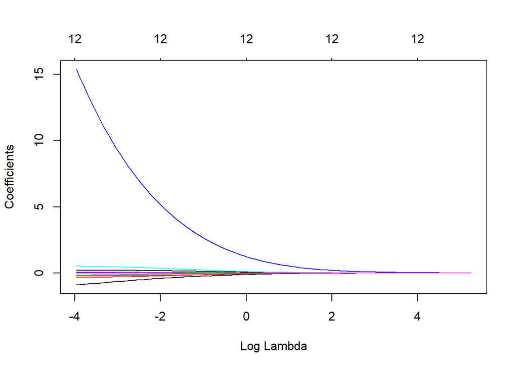

```r
library(glmnet)
## establish matrices
X = model.matrix(~.-card-1,data = creditTrain)
Y = creditTrain$card
## fit model
mod_glm <- glmnet(x = X,
                  y=Y,
                  alpha = 0,family='binomial')
## Explore results
plot(mod_glm,xvar = 'lambda')
```

```r
## Coefficient for lambda = 0
coef(mod_glm,s=0)
```

```
## 13 x 1 sparse Matrix of class "dgCMatrix"
##                         1
## (Intercept) -0.1769700476
## reports     -0.9019625050
## age          0.0021522469
## income       0.0608805520
## share       15.3984033899
## expenditure  0.0045668285
## ownerno     -0.2064472433
## owneryes     0.2062747638
## selfempyes  -0.3237108018
## dependents  -0.1707013507
## months      -0.0002076259
## majorcards   0.5195042468
## active       0.0698771321
```

```r
## Coefficients for lambda = 1
coef(mod_glm,s=1)
```

```
## 13 x 1 sparse Matrix of class "dgCMatrix"
##                         1
## (Intercept)  1.007194e+00
## reports     -1.136021e-01
## age         -1.018902e-04
## income       1.534550e-02
## share        1.242434e+00
## expenditure  3.897276e-04
## ownerno     -7.038335e-02
## owneryes     7.038297e-02
## selfempyes  -6.645137e-02
## dependents  -1.663510e-02
## months      -1.056056e-05
## majorcards   1.135953e-01
## active       5.576156e-03
```

- We could also try out a LASSO, by putting in a value of 1 for alpha.

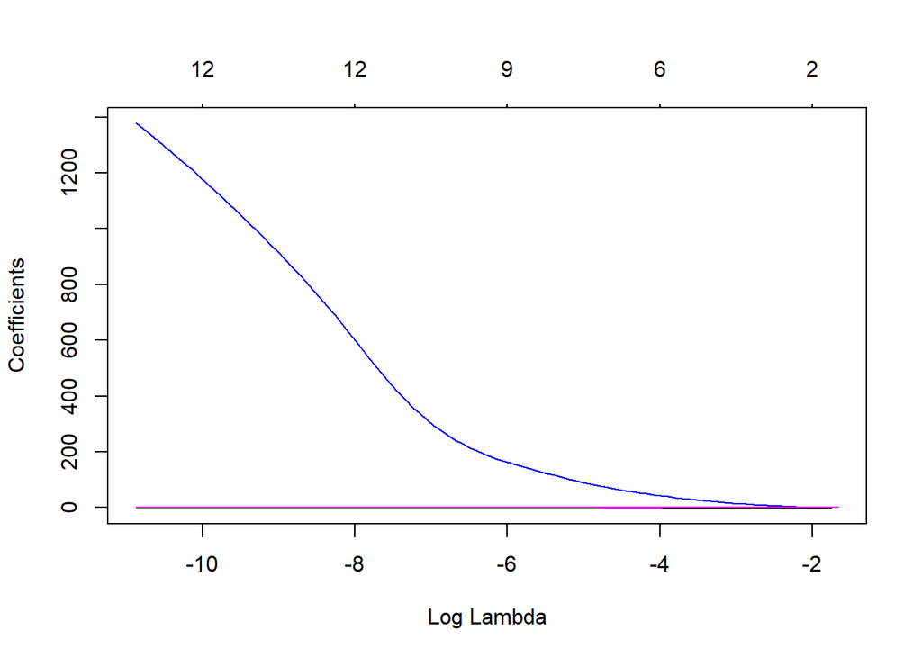

```r
## fit model
mod_glmnet <- glmnet(x = X,
                  y=Y,
                  alpha = 1,family='binomial')
## Explore results
plot(mod_glmnet,xvar = 'lambda')
```

```r
## Coefficient for lambda = 0
coef(mod_glmnet,s=0)
```

```
## 13 x 1 sparse Matrix of class "dgCMatrix"
##                         1
## (Intercept) -3.723506e+00
## reports     -1.798216e+00
## age         -1.253216e-02
## income       6.923234e-02
## share        1.378173e+03
## expenditure  3.429098e-01
## ownerno     -4.416152e-02
## owneryes     2.621099e-01
## selfempyes   4.971694e-01
## dependents  -5.447213e-01
## months       2.723431e-03
## majorcards   1.184150e+00
## active       9.852196e-02
```

```r
## Coefficients for lambda = 1
coef(mod_glmnet,s=1)
```

```
## 13 x 1 sparse Matrix of class "dgCMatrix"
##                    1
## (Intercept) 1.241112
## reports     .
## age         .
## income      .
## share       .
## expenditure .
## ownerno     .
## owneryes    .
## selfempyes  .
## dependents  .
## months      .
## majorcards  .
## active      .
```

- But how do we know which value is best?!?

# Caret and the Elastic Net

- We can use Caret to fit the model, taking advantage of the common syntax from the `train` function.
- The authors of caret have gone to the trouble of identifying what parameters are needed to optimize for a wide range of machine learning classification models.
- In the case of glmnet (elastic net), we just saw that we need to decide on two parameters:
  - Alpha
  - lambda
- If we simply call the caret train function, we will see that the authors have populated a reasonable range of values for these parameters.
- The train function will fit models using a combination of different parameters, then tell us how each one has performed.
- There are more details to be explored on how caret is deciding which model is best, but we will get to that shortly.
- Let’s fit a model first, using the defaults.

```r
## Use caret to fit this model
mod_glmnet <-
  train(card~.,
        data=creditTrain,
        method='glmnet',
        family='binomial')
mod_glmnet
```

```
## glmnet
##
## 990 samples
##  11 predictor
##   2 classes: 'no', 'yes'
##
## No pre-processing
## Resampling: Bootstrapped (25 reps)
## Summary of sample sizes: 990, 990, 990, 990, 990, 990, ...
## Resampling results across tuning parameters:
##
##   alpha  lambda        Accuracy   Kappa
##   0.10   0.0003798827  0.9545880  0.8693349
##   0.10   0.0037988266  0.9353315  0.8022762
##   0.10   0.0379882662  0.8735461  0.5459823
##   0.55   0.0003798827  0.9570248  0.8771406
##   0.55   0.0037988266  0.9453616  0.8369183
##   0.55   0.0379882662  0.8686396  0.5192701
##   1.00   0.0003798827  0.9697795  0.9144175
##   1.00   0.0037988266  0.9552687  0.8719380
##   1.00   0.0379882662  0.8663998  0.5108261
##
## Accuracy was used to select the optimal model using the largest value.
## The final values used for the model were alpha = 1 and lambda = 0.0003798827.
```

- That was a lot of work for not much code!
- Caret tried a range of alpha and lambda parameters (tuning parameters), then summarized the accuracy (and kappa) for each combination of parameters.
- Caret reports that the most accurate combination of parameters was a small lambda (the smallest), along with an alpha == 1. This is based on accuracy.
- The default approach to resampling is the bootstrap approach (more on this next slide).
- Here is a summary from the documentation on exactly what caret just did:

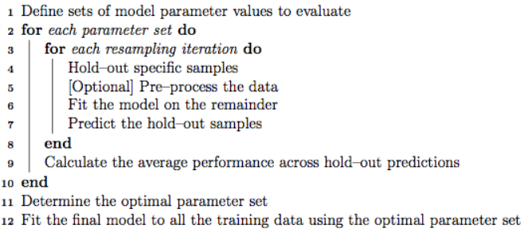

# Model Validation

- In the prior section, we just saw caret somehow used the training data (or parts of the training data) to decide on which tuning parameter combination was ideal.
- This was actually controlled by the `trainControl` argument.
- The default values included a bootstrap approach to resampling, using 25 samples of size 990 each.
  - Bootstrapping just means we sampled (with replacement) from the dataset.
- Another commonly used option is k-folds cross validation.
  - K-folds cross validation involves splitting the data up into k discrete groups.
  - We then fit the model on all but one of those groups, and make predictions on the group we left out.
  - We repeat this k times, then summarize the results.
- We can implement 10 fold cross validation using the following code:

```r
## Define control parameter
trCtrl <- trainControl(method = 'cv',
                       number=10,
                       classProbs = T)
## Use caret to fit this model
mod_glmnet <-
  train(card~.,
        data=creditTrain,
        method='glmnet',
        family='binomial',
        trControl=trCtrl)
mod_glmnet
```

```
## glmnet
##
## 990 samples
##  11 predictor
##   2 classes: 'no', 'yes'
##
## No pre-processing
## Resampling: Cross-Validated (10 fold)
## Summary of sample sizes: 891, 891, 890, 891, 891, 892, ...
## Resampling results across tuning parameters:
##
##   alpha  lambda        Accuracy   Kappa
##   0.10   0.0003798827  0.9574820  0.8780523
##   0.10   0.0037988266  0.9404115  0.8204093
##   0.10   0.0379882662  0.8717423  0.5371567
##   0.55   0.0003798827  0.9595022  0.8845120
##   0.55   0.0037988266  0.9484416  0.8470377
##   0.55   0.0379882662  0.8707524  0.5301850
##   1.00   0.0003798827  0.9717056  0.9215997
##   1.00   0.0037988266  0.9524416  0.8631402
##   1.00   0.0379882662  0.8687320  0.5201901
##
## Accuracy was used to select the optimal model using the largest value.
## The final values used for the model were alpha = 1 and lambda = 0.0003798827.
```

- We end up getting the same values for the hyperparameters whether we use bootstrapping or 10-fold cross validation.

# Comparing Models

- Now let’s see how well the logistic regression model compares with the glmnet model.
- I will first refit the glm using the same control parameters as we just used on the glmnet model.

```r
## Define control parameter
trCtrl <- trainControl(method = 'cv',
                       number=10,
                       classProbs = T)
## Use caret to fit this model
mod_glm <-
  train(card~.,
        data=creditTrain,
        method='glm',
        family='binomial',
        trControl=trCtrl)
mod_glm
```

```
## Generalized Linear Model
##
## 990 samples
##  11 predictor
##   2 classes: 'no', 'yes'
##
## No pre-processing
## Resampling: Cross-Validated (10 fold)
## Summary of sample sizes: 891, 890, 892, 891, 891, 892, ...
## Resampling results:
##
##   Accuracy   Kappa
##   0.8658155  0.626953
```

- Now we can use the resamples function to compare the performance

```r
r1 <-
  resamples(list(glm=mod_glm,
               glmnet=mod_glmnet))
summary(r1)
```

```
##
## Call:
## summary.resamples(object = r1)
##
## Models: glm, glmnet
## Number of resamples: 10
##
## Accuracy
##             Min.   1st Qu.    Median      Mean   3rd Qu.      Max. NA's
## glm    0.7979798 0.8282828 0.8630179 0.8658155 0.8888889 0.9897959    0
## glmnet 0.9489796 0.9696970 0.9700000 0.9717056 0.9797464 0.9898990    0
##
## Kappa
##             Min.   1st Qu.    Median      Mean   3rd Qu.      Max. NA's
## glm    0.4206009 0.5729792 0.6059638 0.6269530 0.6260428 0.9711595    0
## glmnet 0.8602396 0.9164087 0.9190065 0.9215997 0.9410267 0.9702970    0
```

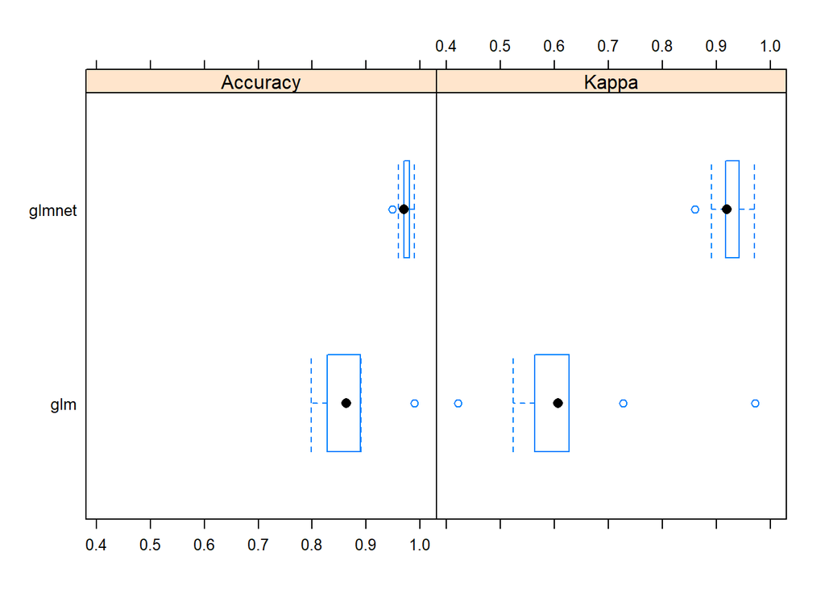

```r
bwplot(r1)
```

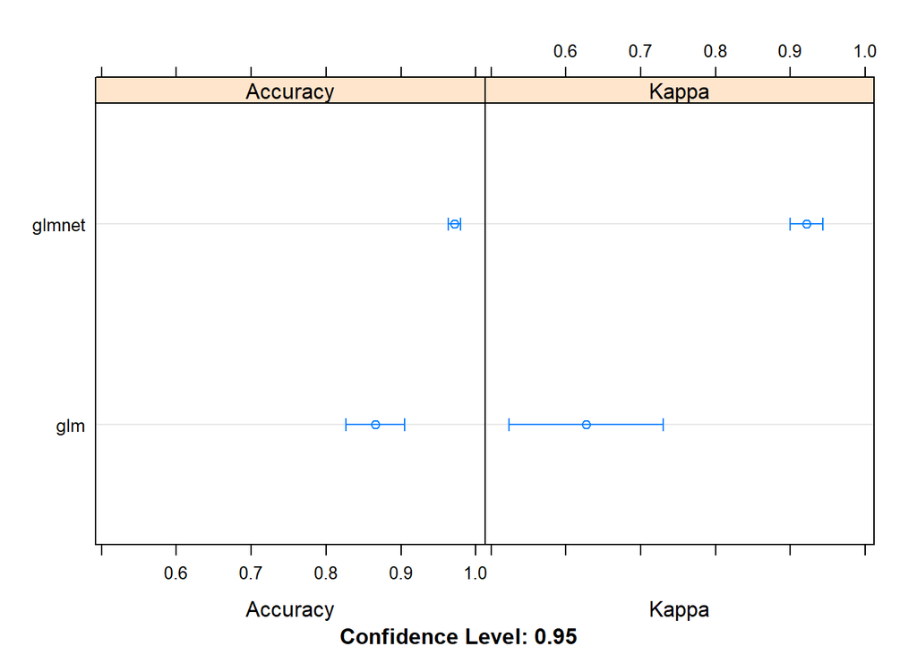

```r
dotplot(r1)
```

- It looks like the glmnet routine did a much better job on our training data.

# Other algorithms

- Caret has implemented over 200 models, all easily accessible via the caret train interface.
- Check out the caret help [page](http://topepo.github.io/caret/) to review all the different models that are available.
- The train function will construct a reasonable range of hyperparameters for a given model, then implement a model validation technique as shown above, then report back the optimal hyperparameters.
- Let’s fit a few more classification techniques, and see how they perform compared with the glm or glmnet.

# Linear Support vector Machine

- Another commonly implemented machine learning classification algorithm is support vector machine with a linear kernel.
- We can explore the parameters of each method by looking at the caret website, or also by using he `modelLookup` function

```r
modelLookup('glm')
```

```
##   model parameter     label forReg forClass probModel
## 1   glm parameter parameter   TRUE     TRUE      TRUE
```

```r
modelLookup('glmnet')
```

```
##    model parameter                    label forReg forClass probModel
## 1 glmnet     alpha        Mixing Percentage   TRUE     TRUE      TRUE
## 2 glmnet    lambda Regularization Parameter   TRUE     TRUE      TRUE
```

```r
modelLookup('svmLinear')
```

```
##       model parameter label forReg forClass probModel
## 1 svmLinear         C  Cost   TRUE     TRUE      TRUE
```

- It looks like the only parameter needed for the linear support vector machine is the Cost parameter.
- We can fit the model using the now familiar syntax below, and simply substitute in the method argument

```r
## Use caret to fit this model
mod_svmLin <-
  train(card~.,
        data=creditTrain,
        method='svmLinear',
        family='binomial',
        trControl=trCtrl)
mod_svmLin
```

```
## Support Vector Machines with Linear Kernel
##
## 990 samples
##  11 predictor
##   2 classes: 'no', 'yes'
##
## No pre-processing
## Resampling: Cross-Validated (10 fold)
## Summary of sample sizes: 891, 891, 892, 892, 891, 891, ...
## Resampling results:
##
##   Accuracy   Kappa
##   0.9535129  0.868197
##
## Tuning parameter 'C' was held constant at a value of 1
```

- Interesting, the tuning parameter C was held constant!
- How can we specify a range of C values for caret to train over?
- We can pass in a grid of values directly, rather than allowing caret to decide.
- We can also specify the length of the tuning grid, but that doesn’t always work (see below here)

```r
## Use caret to fit this model, specify length
mod_svmLin <-
  train(card~.,
        data=creditTrain,
        method='svmLinear',
        trControl=trCtrl,
        tuneLength=5)
mod_svmLin
```

```
## Support Vector Machines with Linear Kernel
##
## 990 samples
##  11 predictor
##   2 classes: 'no', 'yes'
##
## No pre-processing
## Resampling: Cross-Validated (10 fold)
## Summary of sample sizes: 891, 891, 891, 891, 892, 891, ...
## Resampling results:
##
##   Accuracy   Kappa
##   0.9505246  0.8616326
##
## Tuning parameter 'C' was held constant at a value of 1
```

- C was still held constant!

```r
## Use caret to fit this model, specify actual values
grid1 <- expand.grid(C=c(0.2,1,5,10,100))
mod_svmLin <-
  train(card~.,
        data=creditTrain,
        method='svmLinear',
        trControl=trCtrl,
        tuneGrid=grid1)
mod_svmLin
```

```
## Support Vector Machines with Linear Kernel
##
## 990 samples
##  11 predictor
##   2 classes: 'no', 'yes'
##
## No pre-processing
## Resampling: Cross-Validated (10 fold)
## Summary of sample sizes: 892, 891, 892, 891, 891, 891, ...
## Resampling results across tuning parameters:
##
##   C      Accuracy   Kappa
##     0.2  0.9464007  0.8481671
##     1.0  0.9504519  0.8585252
##     5.0  0.9646046  0.9006909
##    10.0  0.9696654  0.9154422
##   100.0  0.9666349  0.9094989
##
## Accuracy was used to select the optimal model using the largest value.
## The final value used for the model was C = 10.
```

- I would also recommend reviewing the details for any model you might fit. However, the beauty of the caret package is that you now have a wide range of models available to you using a common syntax. What you mainly need to know is what the tuning parameters are, and what reasonable values you should try.

# Random Forest

```r
modelLookup('rf')
```

```
##   model parameter                         label forReg forClass probModel
## 1    rf      mtry #Randomly Selected Predictors   TRUE     TRUE      TRUE
```

```r
## fit rf model
## Use caret to fit this model, specify length
mod_rf <-
  train(card~.,
        data=creditTrain,
        method='rf',
        trControl=trCtrl,
        tuneLength=5)
mod_rf
```

```
## Random Forest
##
## 990 samples
##  11 predictor
##   2 classes: 'no', 'yes'
##
## No pre-processing
## Resampling: Cross-Validated (10 fold)
## Summary of sample sizes: 891, 891, 890, 892, 892, 890, ...
## Resampling results across tuning parameters:
##
##   mtry  Accuracy   Kappa
##    2    0.9838380  0.9547970
##    4    0.9838380  0.9547970
##    6    0.9818178  0.9488653
##    8    0.9818178  0.9488653
##   11    0.9808077  0.9458995
##
## Accuracy was used to select the optimal model using the largest value.
## The final value used for the model was mtry = 2.
```

# Classification: Boosted Logistic Regression

- Let’s try a few more models.
- This is a boosted algorithms of weak learners
- From the help, “Train logitboost classification algorithm using decision stumps (one node decision trees) as weak learners.”

```r
modelLookup('LogitBoost')
```

```
##        model parameter                 label forReg forClass probModel
## 1 LogitBoost     nIter # Boosting Iterations  FALSE     TRUE      TRUE
```

```r
## Boosted logistic regression
mod_logit_boost <-
  train(card~.,
        data=creditTrain,
        method = "LogitBoost",
        trControl=trCtrl,
        tuneLength=5)
mod_logit_boost
```

```
## Boosted Logistic Regression
##
## 990 samples
##  11 predictor
##   2 classes: 'no', 'yes'
##
## No pre-processing
## Resampling: Cross-Validated (10 fold)
## Summary of sample sizes: 891, 891, 892, 891, 891, 891, ...
## Resampling results across tuning parameters:
##
##   nIter  Accuracy   Kappa
##   11     0.9808172  0.9460124
##   21     0.9818275  0.9487717
##   31     0.9787969  0.9397644
##   41     0.9778073  0.9369146
##   51     0.9788174  0.9399814
##
## Accuracy was used to select the optimal model using the largest value.
## The final value used for the model was nIter = 21.
```

# Resamples Across all the Algorithms

- Let’s examine the resamples across all the models we have fit so far.
- Which one would you pick as the ‘best’ predictive model?
- Can you make predictions on the testing data using that model, and see how well it performs?

```r
r2 <-
  resamples(list(glm=mod_glm,
                 glmnet=mod_glmnet,
                 logit_boost=mod_logit_boost,
                 rf=mod_rf,
                 svmLin=mod_svmLin))
summary(r2)
```

```
##
## Call:
## summary.resamples(object = r2)
##
## Models: glm, glmnet, logit_boost, rf, svmLin
## Number of resamples: 10
##
## Accuracy
##                  Min.   1st Qu.    Median      Mean   3rd Qu.      Max. NA's
## glm         0.7979798 0.8282828 0.8630179 0.8658155 0.8888889 0.9897959    0
## glmnet      0.9489796 0.9696970 0.9700000 0.9717056 0.9797464 0.9898990    0
## logit_boost 0.9600000 0.9796434 0.9797980 0.9818275 0.9873737 1.0000000    0
## rf          0.9494949 0.9797980 0.9848980 0.9838380 0.9898732 1.0000000    0
## svmLin      0.9494949 0.9620439 0.9695424 0.9696654 0.9772727 0.9900000    0
##
## Kappa
##                  Min.   1st Qu.    Median      Mean   3rd Qu.      Max. NA's
## glm         0.4206009 0.5729792 0.6059638 0.6269530 0.6260428 0.9711595    0
## glmnet      0.8602396 0.9164087 0.9190065 0.9215997 0.9410267 0.9702970    0
## logit_boost 0.8935604 0.9414303 0.9423899 0.9487717 0.9642836 1.0000000    0
## rf          0.8606811 0.9433962 0.9573471 0.9547970 0.9712244 1.0000000    0
## svmLin      0.8606811 0.8954057 0.9161438 0.9154422 0.9366493 0.9721913    0
```

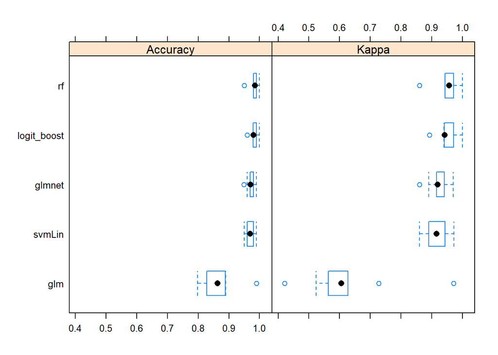

```r
bwplot(r2)
```

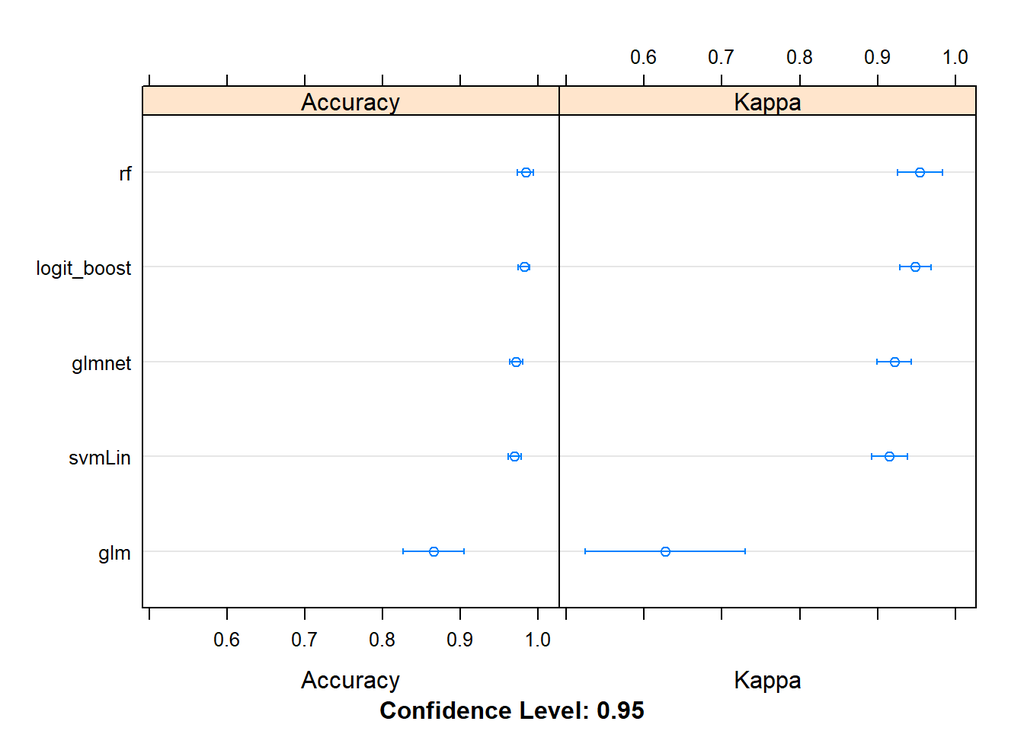

```r
dotplot(r2)
```

# Final Performance on the Testing Data

- I will pick the random forest as the winner, and use it to make predictions on the testing data.
- How good was this model?

```r
## Evaluate performance on Testing Data
dfTest$pred_rf <-
  predict(mod_rf,
          newdata = creditTest,
          type='raw')
with(dfTest,
     confusionMatrix(pred_rf,card))
```

```
## Confusion Matrix and Statistics
##
##           Reference
## Prediction  no yes
##        no   74   9
##        yes   0 246
##
##                Accuracy : 0.9726
##                  95% CI : (0.9487, 0.9874)
##     No Information Rate : 0.7751
##     P-Value [Acc > NIR] : < 2.2e-16
##
##                   Kappa : 0.9248
##
##  Mcnemar's Test P-Value : 0.007661
##
##             Sensitivity : 1.0000
##             Specificity : 0.9647
##          Pos Pred Value : 0.8916
##          Neg Pred Value : 1.0000
##              Prevalence : 0.2249
##          Detection Rate : 0.2249
##    Detection Prevalence : 0.2523
##       Balanced Accuracy : 0.9824
##
##        'Positive' Class : no
##
```

- This model fit very well, and had a high predictive accuracy level.
- That will not always be the case in many real life situations!
- Remember there is no Santa Claus - and machine learning won’t magically make great predictions unless there is good (predictive) data used as inputs ;) If the process you are modeling is not heavily impacted by your observed predictors (inputs), machine learning won’t ‘fix’ that.